# Customizing colors in R

Colors can be defined in R in at least three ways: by **number**, by **name** and by **RGB** designation. There are other color palette packages such as `RColorBrewer` that provide additional control over color schemes.

## Color numbers

There are 8 color numbers to choose from, for example:

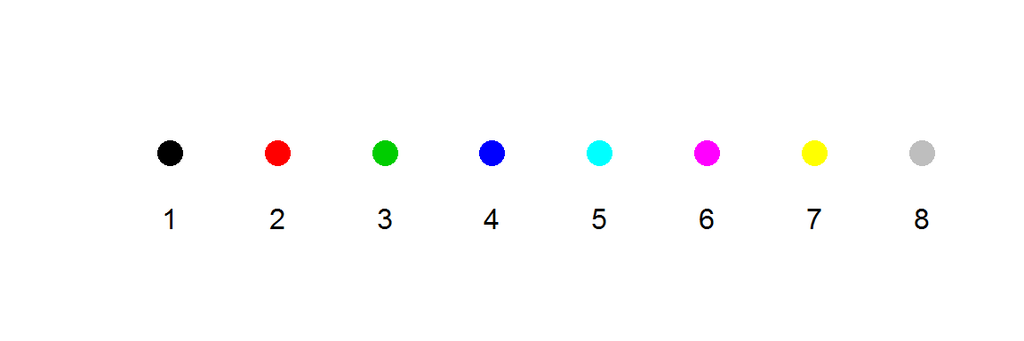

```r
plot(1:8, rep(1,8), axes = FALSE, col=1:8, pch=16, cex=2,xlab=NA, ylab=NA)
axis(1, sprintf("%i", 1:8),col="white")
```

## Color names

R offers a big list of color names–too big to list on this page. The names can be accessed via the `colors()` function.

```r
colors()
```

In the following example, we display a subset of these colors.

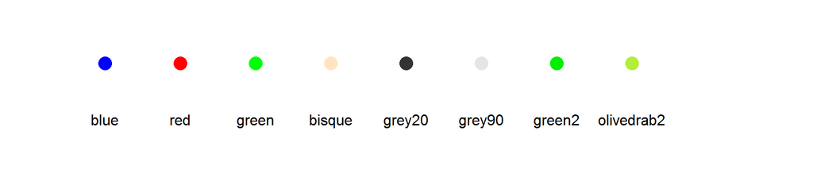

```r
col.lst <- c("blue" , "red", "green" , "bisque", "grey20", "grey90", "green2", "olivedrab2")
plot(1:8, rep(1,8), axes = FALSE, pch=16, cex=2, col=col.lst, xlab=NA, ylab=NA,
     xlim = c(0, 10))
axis(1, at=1:8, labels = sprintf("%s", col.lst), col="white", cex=0.6, padj=-3)
```

## RGB designation

Colors can also be defined by the computer display’s primary colors; red, green and blue (RGB for short). One can use the `rgb()` function to define the levels of each primary color from a scale of 0 to 1 with one being the color’s maximum intensity. For example, if you want to generate a pure blue color, type:

```r
rgb(0,0,1)
```

```
[1] "#0000FF"
```

The function returns a hexadecimal value, #0000FF, which R can convert to a color. For example to plot blue points, type:

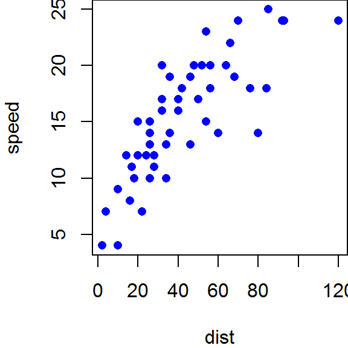

```r
plot( speed ~ dist, cars, pch=16, col=rgb(0,0,1))
```

A fourth parameter can be passed to `rgb()`: the opaqueness value `alpha`. This is useful when many overlapping points are displayed on a plot. `alpha` is defined in an interval from 0 to 1 with 1 being completely opaque and 0 being completely transparent. In the following example, we apply a blue color to the dots and assign them a 80% transparency (alpha = 0.2):

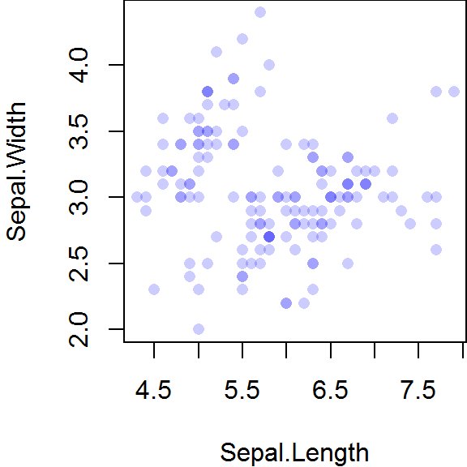

```r
plot( Sepal.Width ~ Sepal.Length, iris , pch=16, col=rgb(0,0,1, 0.2))
```

Manny Gimond (2016)